## Analysis of the Carpentries Instructor Training Post-Workshop Survey Data

**Lead:** [Kari L. Jordan](https://github.com/kariljordan)

This analysis of The Carpentries Instructor Training [post-workshop survey](https://github.com/carpentries/assessment/blob/master/programmatic-assessment/instructor-training/surveys/current_survey.pdf) serves to offer recommendations for changes to curriculum and assessment of The Carpentries instructor training program.

There were a total 573 trainees who completed this survey in between June 2016 and February 2018.

### When are trainees completing the post instructor training survey?

| When are you taking the survey? | n | % |
| --- | --- | --- |
| I have just completed the training, and am taking it at the event | 409 | 71 |
| I have recently completed the training, and am taking it after I left the event | 164 | 29 |

### Demographics

| Domain of research/work/study | n | % |
| --- | --- | --- |
| Life Sciences (Genetics, genomics, bioinformatics ) | 126 | 26.6 |
| Life Science - Organismal/systems (ecology, botany, zoology, microbiology, neuroscience) | 106 | 22.4 |
| High performance computing | 82 | 17.3 |
| Mathematics/statistics | 58 | 12.2 |
| Library and information science | 54 | 11.4 |
| Physics | 50 | 10.5 |
| Planetary sciences (geology, climatology, oceanography, etc.) | 38 | 8.0 |
| Social sciences | 33 | 7.0 |
| Humanities | 27 | 5.7 |
| Economics/business | 24 | 5.1 |
| Education | 24 | 5.1 |
| Chemistry | 20 | 4.2 |
| Space sciences | 20 | 4.2 |
| Civil, mechanical, chemical, or nuclear engineering | 19 | 4.0 |
| Medicine and/or Pharmacy | 12 | 2.5 |
| Psychology | 8 | 1.7 |

Nearly half (49%) of our instructor trainees are from the life sciences, with another third (29.5%) coming from either computing or mathematics/statistics. These figures highlight the need to expand our training efforts into other disciplines, particularly those in which we are developing new curricula, including social sciences, economics, business, and chemistry. To ensure that new curricula are able to be delivered to researchers in the target domains, it is essential that we train instructors in those domains who will be able to teach those curricula.

**Position**

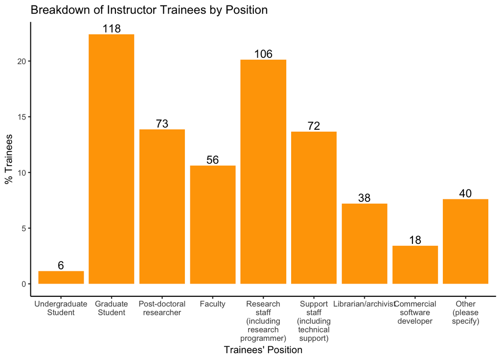

To inform our efforts to improve the diversity of our instructor community, we collect additional demographic information from U.S. participants. This information is completely voluntary. Trainees were asked to self-report how they identify themselves by selecting among various racial/ethnic groups and to describe their gender identity.

| Racial/Ethnic Identity | n | % |
| --- | --- | --- |
| White | 272 | 70 |
| Asian | 53 | 14 |
| Hispanic or Latino(a) | 24 | 6 |
| Prefer not to say | 20 | 5 |
| Multiple ethnicity / Other (please specify) | 15 | 4 |
| Black or African American | 6 | 2 |
| American Indian or Alaska Native | 1 | 0 |

Our US instructor body is not representative of the US population as a whole, illustrating the need for us to actively recruit from and provide more opportunities for involvement for researchers and other professionals from diverse ethnic and racial backgrounds. As many of our instructors come from member institutions, one avenue to increasing the diversity of our instructor body is working with historically black colleges and universities, hispanic serving institutions, and tribal colleges to promote membership within those institutions.

| Gender Identity | n | % |
| --- | --- | --- |
| Male | 234 | 59 |
| Female | 143 | 36 |
| Prefer not to say | 15 | 4 |
| Other | 5 | 1 |

Although a large proportion of our instructors are female, we have not yet reached gender parity in our instructor community. (Note to Kari: It would be informative to know whether this is representative of the applications we receive or if we’re disproportionatly selecting male applicants. I analyzed this about a year ago (carpentry-private-data/instructor-assessment/scripts/training-requests.html) and we were accepting a higher proportion of female applicants at that time compared to application rates.)

## Feedback about the overall training event.

We are interested to know how much of the information presented at Carpentries instructor training events is new. The following table shows that about one third of trainees fall into either some, about half, or most of the information being new to them.

| How much information was new? | n | % |
| --- | --- | --- |
| None of it | 1 | 0 |
| Some of it | 156 | 30 |
| About half of it | 173 | 33 |
| Most of it | 188 | 36 |

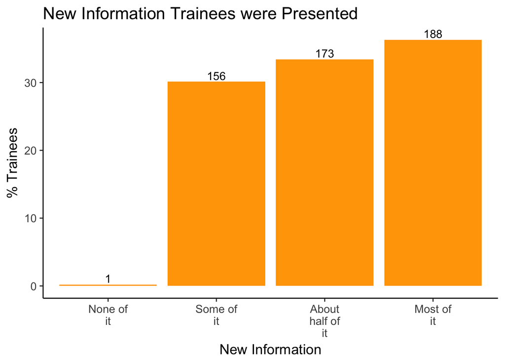

Trainees were asked to rate their level of agreement about the following statements as it relates to the overall training event.

- **Worth**: The training was worth my time.
- **Recommend**: I would recommend this training to a friend/colleague.
- **Material**: The material preented matched the description of the training event.
- **LearnedSkills**: I learned skills that I will be able to use in my teaching.
- **InformationReasonableTime**: The amount of information covered was reasonable for alloted time.
- **AtmosphereWelcoming**: The overall atmosphere was welcoming.

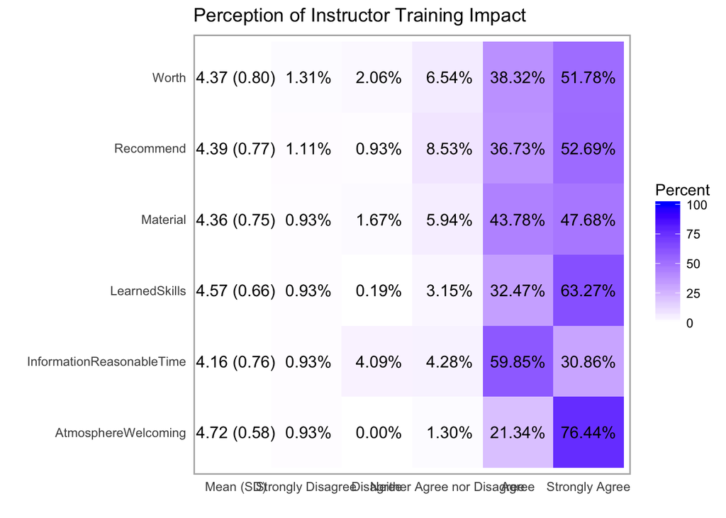

Trainees were asked how they perceived the pace of the training.

| Training Pace | n | % |
| --- | --- | --- |
| Too slow | 17 | 3 |
| Slightly slow | 153 | 28 |
| Just right | 301 | 56 |
| Slightly fast | 63 | 12 |
| Too fast | 3 | 1 |

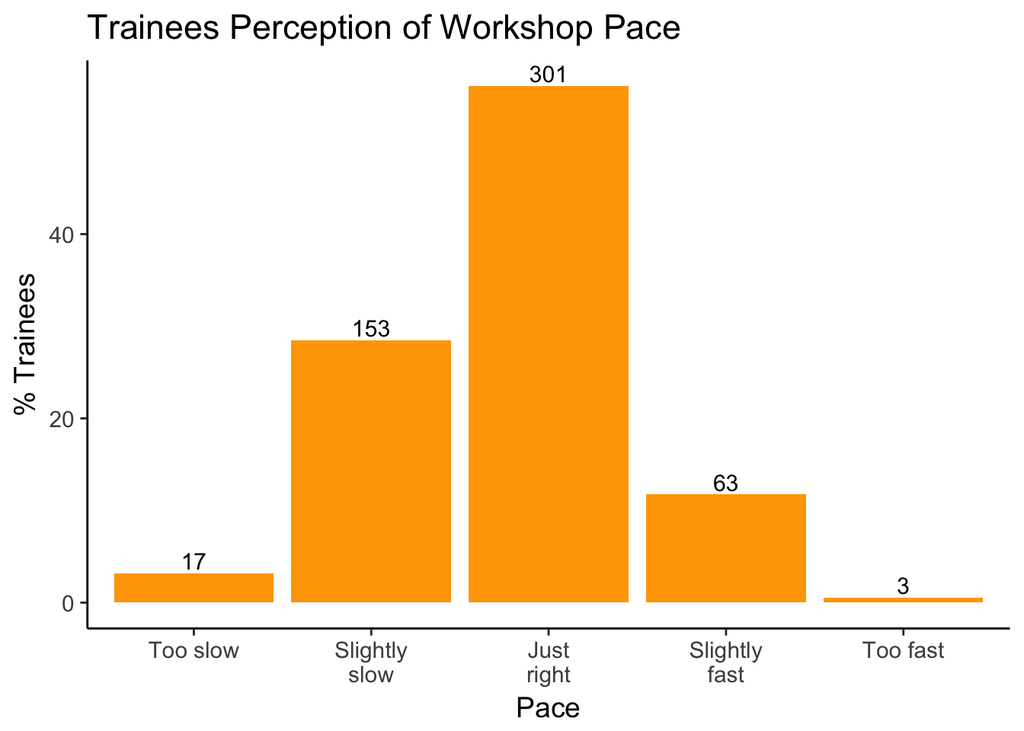

Trainees were also asked to rate the balance of lecture to hands-on work.

| Balance of Lecture to Hands-On | n | % |
| --- | --- | --- |
| Too much lecture | 16 | 3 |
| Slightly too much lecture | 154 | 29 |
| Balanced (lecture/hands-on) | 336 | 62 |
| Slightly too much hands-on | 26 | 5 |
| Too much hands-on | 7 | 1 |

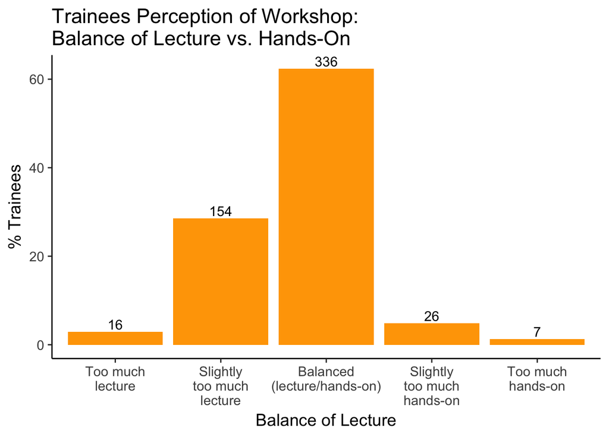

## About the Instructors and Helpers

Trainees were asked to select how they felt the instructor trainers(s) performed based on the following:

- **Enthusiastic**: Instructor trainer(s) were enthusiastic.
- **Considerate**: Instructor trainer(s) were considerate.
- **Communicators**: Instructor trainer(s) were good communicators.
- **ClearAnswers**: Instructor trainer(s) gave clear answers to your questions.

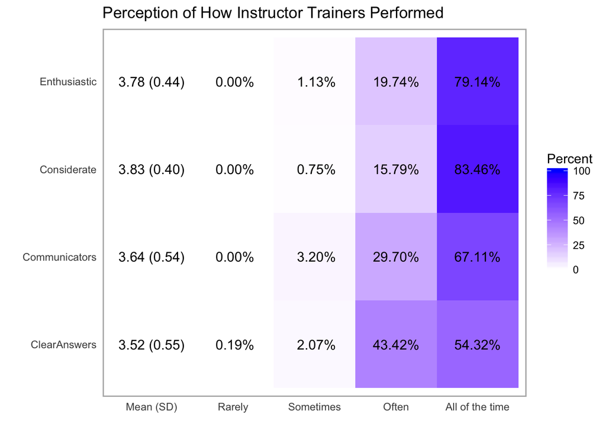

Trainees were asked to describe their experience with the following topics before the training, and their change in knowledge of these topics after the training. The topics are as follows:

- **Assessment**: Formative vs. summative assessment
- **BackwardsDesign**: Backwards design
- **Carpentries**: What the Carpentries are and what they do
- **Cognition**: Levels of cognition
- **CognitiveLoad**: Cognitive load
- **Feedback**: Giving effective feedback
- **Memory**: How human memory works
- **Motiation**: Motivation
- **Novice**: What makes someone a novice or expert

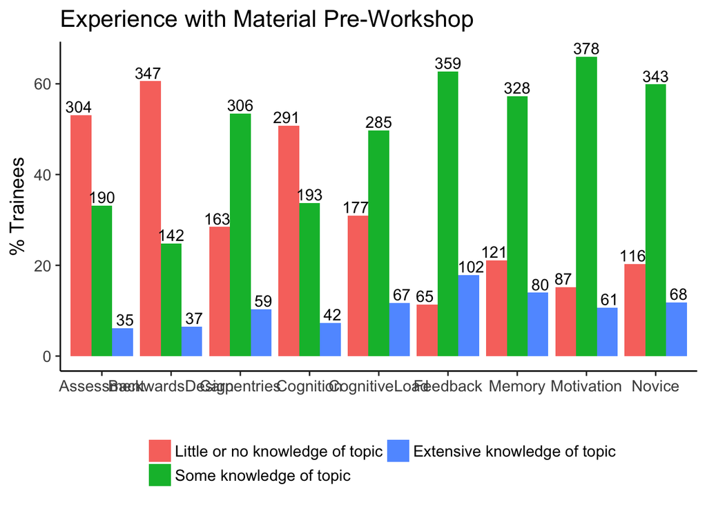

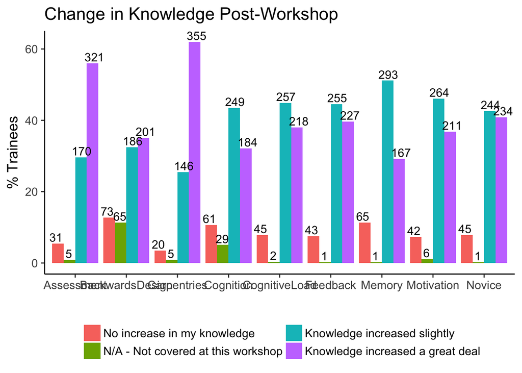

Trainees were asked how their motivation to learn more about the topics below changed:

- **Assessment**: Formative vs. summative assessment
- **BackwardsDesign**: Backwards design
- **Carpentries**: What the Carpentries are and what they do
- **Cognition**: Levels of cognition
- **CognitiveLoad**: Cognitive load
- **Feedback**: Giving effective feedback
- **Memory**: How human memory works
- **Motiation**: Motivation
- **Novice**: What makes someone a novice or expert

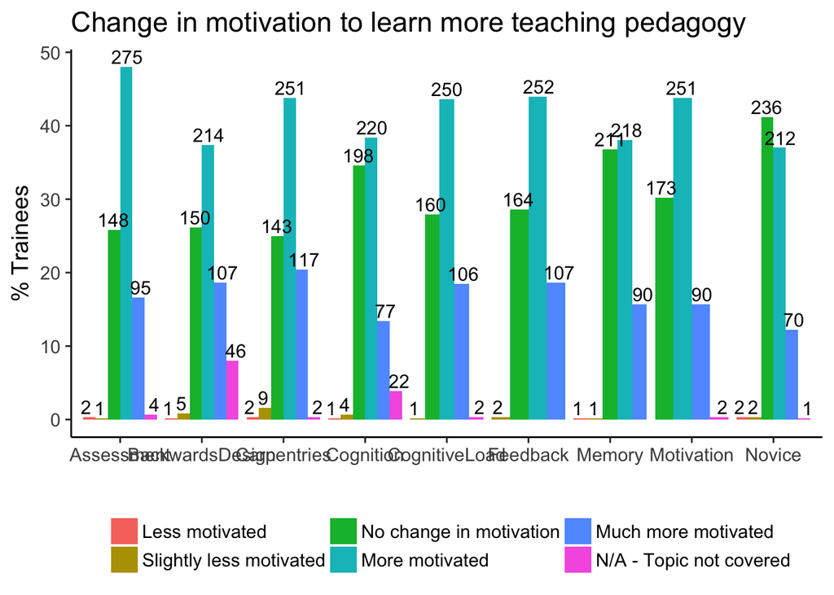

## Change in confidence with Carpentries teaching practices

Trainees were asked to rate their ability before the training, and their change in confidence after the training, for the following items:

- **ConceptMaps**: Use a concept map for lesson planning
- **Learning Objectives**: Write effective learning objectives
- **LiveCoding**: Teach using live coding
- **MCQ**: Write a multiple choice question with diagnostic power
- **Website**: Set up a workshop website

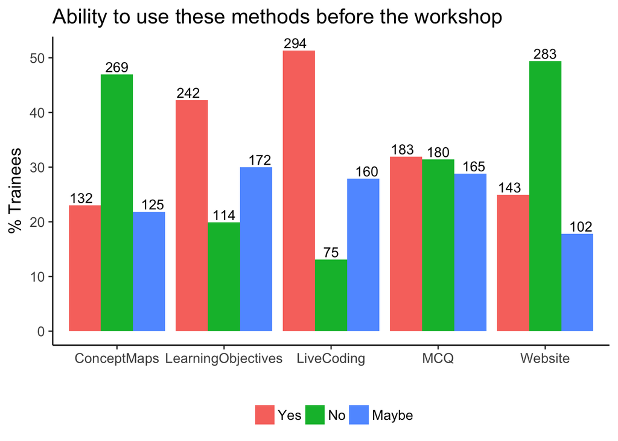

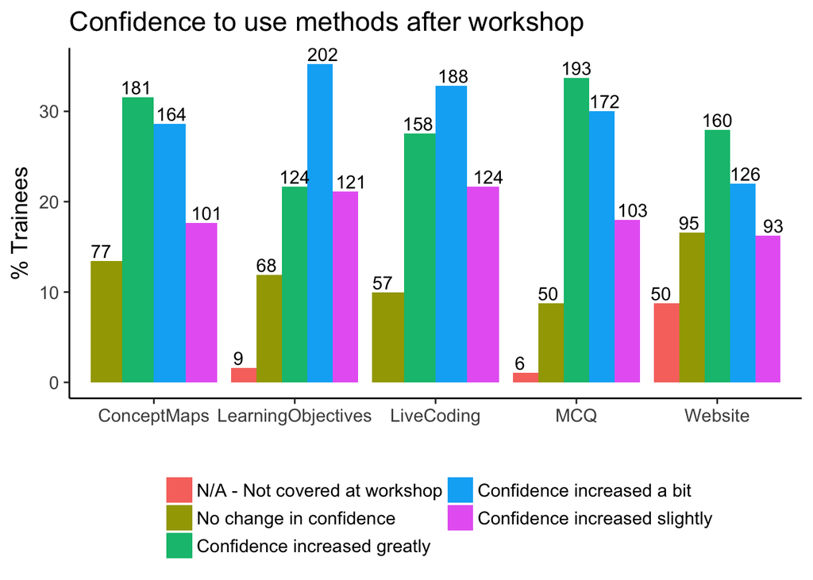

Trainees were asked if they have a clear understanding of what needs to be done to complete instructor training.

| Clear on Checkout Process? | n | % |
| --- | --- | --- |
| No, not clear at all | 1 | 0 |
| Could use some more details | 73 | 14 |
| Yes, I understand | 451 | 86 |

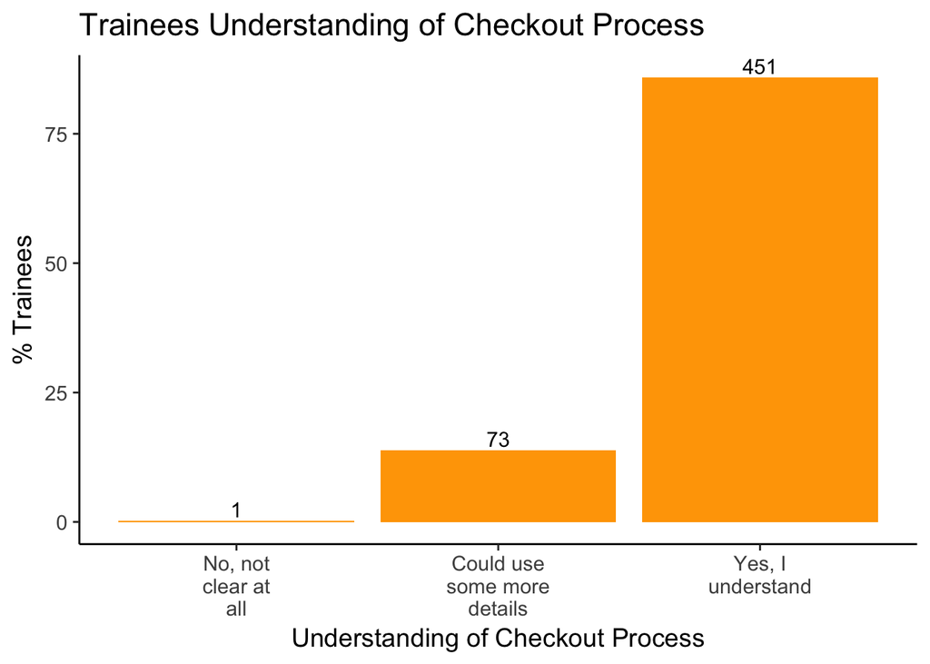

## Recommending Carpentries’ Instructor Training

Trainees were asked how likely they are to recommend a Software and/or Data Carpentry workshop to a friend or colleague using the [Net Promoter Score](https://en.wikipedia.org/wiki/Net_Promoter). The scoring for this question based on a 0 to 10 scale. Trainees scoring from 0 to 6.4 are labeled *Detractors*, and are believed to be less likely to recommend a workshop. Those who respond with a score of 8.5 to 10 are called *Promoters*, and are considered likely to recommend a workshop. Trainees between 6.5 and 8.4 are labeled *Passives*, and their behavior falls in the middle of Promoters and Detractors.

| category | n | % |
| --- | --- | --- |
| Detractor | 35 | 6.628788 |
| Passive | 179 | 33.901515 |
| Promoter | 314 | 59.469697 |

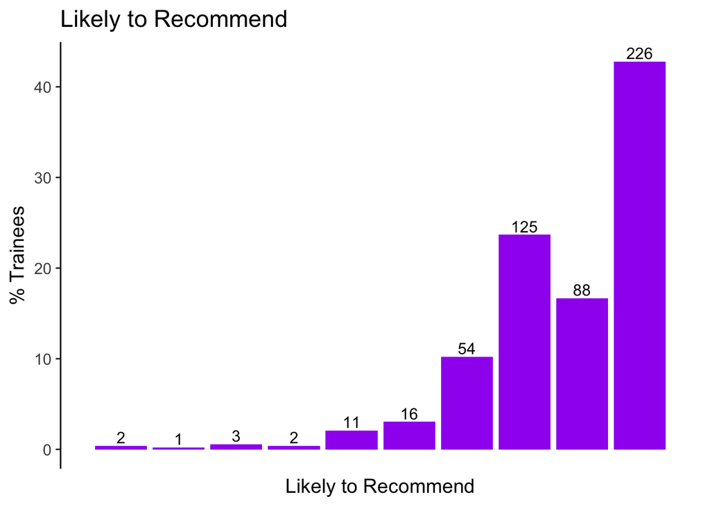